# Contingency Tables

2018-02-27

## One-inflated Poisson (not contingency tables)

Suppose $X \sim Poisson(\mu)$ with pmf $f_X(y)$ for $y \in \mathbb{N}_0$ which is just the pmf for the Poisson.

Suppose $Z$ is 1 due to some structural phenomonenon. Then $Z \sim Bernoulli(p)$ where success denotes $Z=1$. This has pmf $f_Z(y)$ $= p^y (1-p)^{1-y}$.

Then let $Y ~$ 1-inflated Poisson with pmf $f_Y(y)$.

Then $f_Y(0) = f_X(0) = e^{-\mu}$.

But $f_Y(1) = \phi (1 - f_X(0)) + (1 - \phi) f_X(1)$ where $\phi$ is the probability that $Z = 1$ and $(1 - \phi) = P(Z =0)$.

Then $f_Y(y) = (1 - \phi) f_X(y)$ for $y = 2, 3, 4, ...$.

For implementation, use package `VGAM`.

# Contingency tables

Model in the form of `y ~ x1 + x2`

Let $y$ be a count and $x_i$ be factors. Then we can use the Poisson model. From this model, we can compute the deviance, which is a $\chi^2$ test statistic with $n-p$ degrees of freedom. If the $p$-value for this is small, then we have evidence to reject $H_0$ that the $x_i$s are independent.

Another way to look at this is via additive models.

## Additive models

$$\log \mu = \gamma + \alpha_i + \beta_j$$

Where $\gamma$ is the intercept, $i = 1, ..., I$, and $j = 1, .., J$. $\alpha$ and $\beta$ are ordinal variables

## Example (for contingency tables)

Model: $\eta = \beta_0 + \beta_1 U_2 + \beta_2 V_2$

```r
library(faraway)

y <- c(320, 14, 80, 36)
particle <- gl(2, 1, 4, labels = c('no', 'yes'))
quality <- gl(2, 2, labels = c('good', 'bad'))
wafer = data.frame(y, particle, quality)
wafer
```

```
    y particle quality
1 320       no    good
2  14      yes    good
3  80       no     bad
4  36      yes     bad
```

```r
ov <- xtabs(y ~ quality + particle)
ov
```

```
       particle
quality  no yes
   good 320  14
   bad   80  36
```

```r
m1 <- glm(y ~ quality + particle, poisson)
summary(m1)
```

```
Call:
glm(formula = y ~ quality + particle, family = poisson)

Deviance Residuals:
     1       2       3       4
 1.324  -4.350  -2.370   5.266

Coefficients:
            Estimate Std. Error z value Pr(>|z|)
(Intercept)   5.6934     0.0572  99.535   <2e-16 ***
qualitybad   -1.0575     0.1078  -9.813   <2e-16 ***
particleyes  -2.0794     0.1500 -13.863   <2e-16 ***
---
Signif. codes:  0 '***' 0.001 '**' 0.01 '*' 0.05 '.' 0.1 ' ' 1

(Dispersion parameter for poisson family taken to be 1)

    Null deviance: 474.10  on 3  degrees of freedom
Residual deviance:  54.03  on 1  degrees of freedom
AIC: 83.774

Number of Fisher Scoring iterations: 5
```

Checking for independence

- $H_0$ : particle and quality are independent
- $H_1$ : particle and quality are dependent

Based on the deviance, we reject $H_0$.

```r
m2 <- glm(y ~ particle * quality, poisson)
deviance(m2)
```

```
[1] 3.641532e-14
```

```r
drop1(m1, test = 'Chi')
```

```
Single term deletions

Model:
y ~ quality + particle
         Df Deviance    AIC    LRT  Pr(>Chi)
<none>         54.03  83.77
quality   1   164.22 191.96 110.19 < 2.2e-16 ***
particle  1   363.91 391.66 309.88 < 2.2e-16 ***
---
Signif. codes:  0 '***' 0.001 '**' 0.01 '*' 0.05 '.' 0.1 ' ' 1
```

This is a saturated model.

```r
t(model.matrix(m1)) %*% y
```

```
            [,1]
(Intercept)  450
qualitybad   116
particleyes   50
```

```r
pp <- prop.table(xtabs(y ~ particle))
pp
```

```
particle
       no       yes
0.8888889 0.1111111
```

```r
qp <- prop.table(xtabs(y ~ quality))
qp
```

```
quality
     good       bad
0.7422222 0.2577778
```

```r
fv <- outer(qp, pp) * 450
fv
```

```
       particle
quality       no      yes
   good 296.8889 37.11111
   bad  103.1111 12.88889
```

```r
.8889 * .7422 * 450
```

```
[1] 296.8837
```

```r
2 * sum(ov * log(ov / fv))  # deviance
```

```
[1] 54.03045
```

```r
sum((ov - fv) ** 2 / fv)  # pearson chi-sq statistic
```

```
[1] 62.81231
```

```r
prop.test(ov)
```

```
    2-sample test for equality of proportions with continuity correction

data:  ov
X-squared = 60.124, df = 1, p-value = 8.907e-15
alternative hypothesis: two.sided
95 percent confidence interval:
 0.1757321 0.3611252
sample estimates:
   prop 1    prop 2
0.9580838 0.6896552
```

```r
# do the same thing with binomial model
m <- matrix(y, nrow = 2)
m
```

```
     [,1] [,2]
[1,]  320   80
[2,]   14   36
```

```r
m3 <- glm(m ~ 1, family = binomial)
summary(m3)
```

```
Call:
glm(formula = m ~ 1, family = binomial)

Deviance Residuals:
     1       2
 2.715  -6.831

Coefficients:
            Estimate Std. Error z value Pr(>|z|)
(Intercept)   1.0576     0.1078   9.813   <2e-16 ***
---
Signif. codes:  0 '***' 0.001 '**' 0.01 '*' 0.05 '.' 0.1 ' ' 1

(Dispersion parameter for binomial family taken to be 1)

    Null deviance: 54.03  on 1  degrees of freedom
Residual deviance: 54.03  on 1  degrees of freedom
AIC: 66.191

Number of Fisher Scoring iterations: 3
```

```r
deviance(m3)
```

```
[1] 54.03045
```

The binomial model is $\log \frac{p}{1-p} = \beta_0$

Fisher test:

```r
fisher.test(ov)
```

```
    Fisher's Exact Test for Count Data

data:  ov
p-value = 2.955e-13
alternative hypothesis: true odds ratio is not equal to 1
95 percent confidence interval:
  5.090628 21.544071
sample estimates:
odds ratio
  10.21331
```

Useful for sparse data

Better than the deviance, but becomes complicated for tables larger than $2 \times 2$

Large two-way tables

```r
data(haireye)
haireye
```

```
     y   eye  hair
1    5 green BLACK
2   29 green BROWN
3   14 green   RED
4   16 green BLOND
5   15 hazel BLACK
6   54 hazel BROWN
7   14 hazel   RED
8   10 hazel BLOND
9   20  blue BLACK
10  84  blue BROWN
11  17  blue   RED
12  94  blue BLOND
13  68 brown BLACK
14 119 brown BROWN
15  26 brown   RED
16   7 brown BLOND
```

```r
ct <- xtabs(y ~ hair + eye, haireye)
ct
```

```
       eye
hair    green hazel blue brown
  BLACK     5    15   20    68
  BROWN    29    54   84   119
  RED      14    14   17    26
  BLOND    16    10   94     7
```

```r
summary(ct)
```

```
Call: xtabs(formula = y ~ hair + eye, data = haireye)
Number of cases in table: 592
Number of factors: 2
Test for independence of all factors:
    Chisq = 138.29, df = 9, p-value = 2.325e-25
```

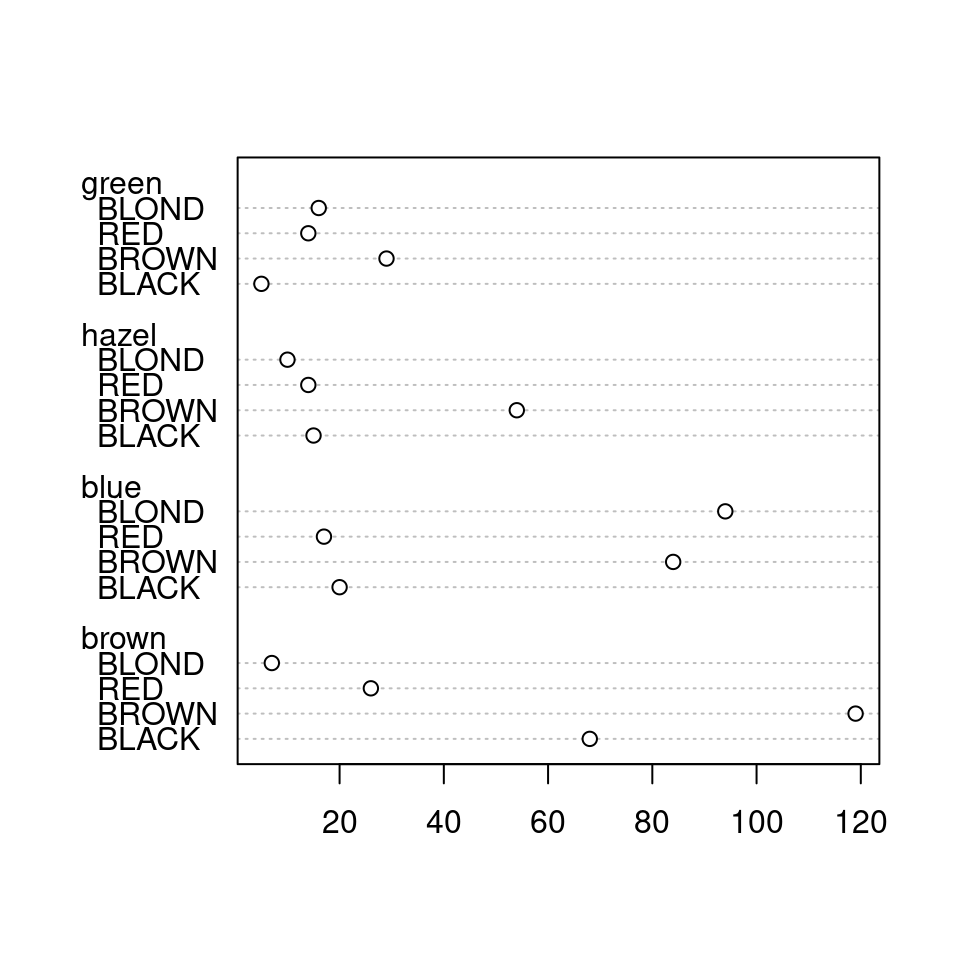

```r
dotchart(ct)
```

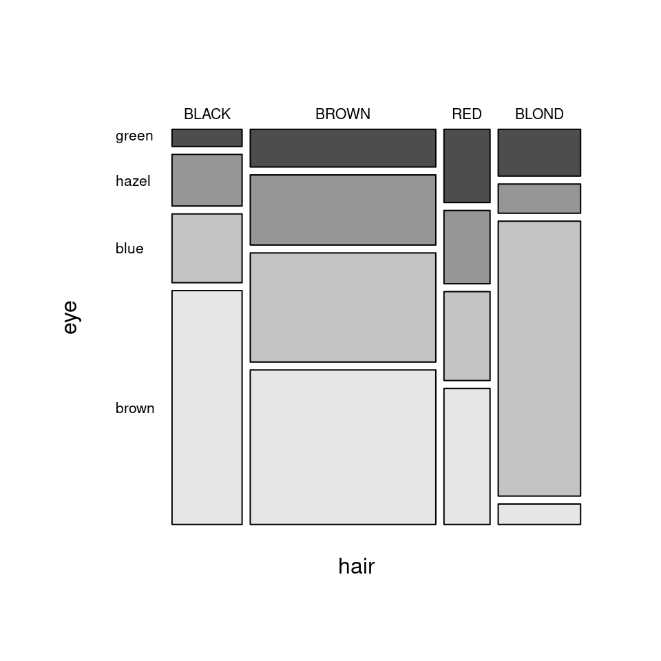

```r
mosaicplot(ct, color=TRUE, main=NULL, las=1)
```

## Correspondence analysis and singular value decomposition

For factors with more than two levels

Graphical analysis

```r
m4 <- glm(y ~ hair + eye, family = poisson, haireye)
summary(m4)
```

```
Call:
glm(formula = y ~ hair + eye, family = poisson, data = haireye)

Deviance Residuals:
   Min      1Q  Median      3Q     Max
-7.326  -2.065  -0.212   1.235   6.172

Coefficients:
            Estimate Std. Error z value Pr(>|z|)
(Intercept)   2.4575     0.1523  16.136  < 2e-16 ***
hairBROWN     0.9739     0.1129   8.623  < 2e-16 ***
hairRED      -0.4195     0.1528  -2.745  0.00604 **
hairBLOND     0.1621     0.1309   1.238  0.21569
eyehazel      0.3737     0.1624   2.301  0.02139 *
eyeblue       1.2118     0.1424   8.510  < 2e-16 ***
eyebrown      1.2347     0.1420   8.694  < 2e-16 ***
---
Signif. codes:  0 '***' 0.001 '**' 0.01 '*' 0.05 '.' 0.1 ' ' 1

(Dispersion parameter for poisson family taken to be 1)

    Null deviance: 453.31  on 15  degrees of freedom
Residual deviance: 146.44  on  9  degrees of freedom
AIC: 241.04

Number of Fisher Scoring iterations: 5
```

```r
z <- xtabs(residuals(m4, type = 'pearson') ~ hair + eye, haireye)
svdz <- svd(z, nu = 2, nv = 2)
svdz
```

```
$d
[1] 1.111726e+01 3.627417e+00 1.240273e+00 1.678879e-10

$u
            [,1]       [,2]
[1,] -0.47166009  0.6154461
[2,] -0.22552151 -0.1522951
[3,] -0.09817011 -0.7424993
[4,]  0.84678181  0.2161646

$v
           [,1]       [,2]
[1,]  0.1163980 -0.7477267
[2,] -0.1844169 -0.4450167
[3,]  0.7220003  0.3353208
[4,] -0.6566258  0.3611439
```

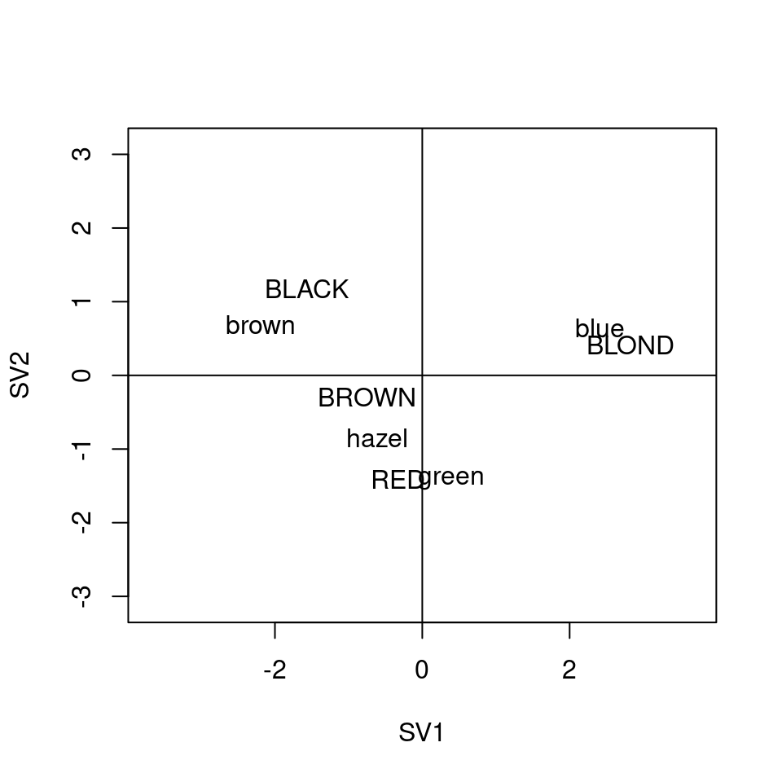

```r
leftsv <- svdz$u %*% diag(sqrt(svdz$d[1:2]))
rightsv <- svdz$v %*% diag(sqrt(svdz$d[1:2]))
ll <- 1.1* max(abs(rightsv),abs(leftsv))
plot(rbind(leftsv, rightsv),
     asp=1,
     xlim=c(-ll, ll), ylim=c(-ll, ll),
     xlab="SV1", ylab="SV2",
     type="n")
abline(h=0, v=0)
text(leftsv, dimnames(z)[[1]])
text(rightsv, dimnames(z)[[2]])
```

Then we can see that `blue` and `BLONDE` are positively associated, `BLACK` and `blue` are negatively associated, and `BROWN` has relatively little association with any of the eye colors.

If two catgegories of the same variable type are close to each other, there is some evidence that they could be merged into one category (e.g., `hazel` and `green`).

## Ordinal Variables

Start with two ariables that are ordinal—we can assign scores

Rows: $u_1 \leq u_2 \leq \cdots \leq u_I$  
Columns: $v_1 \leq \cdots \leq v_J$

Introduce values in the model to obtain a more powerful tool to test association

The model: linear-by-linear association model

$$\log(E[Y_{ij}]) = \log \mu_{ij} = \log (np_{ij}) =
\log n + \alpha_i + \beta_j + \gamma u_i v_j$$

$\gamma$ acts like a correlation coefficient

```r
data(nes96)
xtabs(~ PID + educ, nes96)
```

```
         educ
PID       MS HSdrop HS Coll CCdeg BAdeg MAdeg
  strDem   5     19 59   38    17    40    22
  weakDem  4     10 49   36    17    41    23
  indDem   1      4 28   15    13    27    20
  indind   0      3 12    9     3     6     4
  indRep   2      7 23   16     8    22    16
  weakRep  0      5 35   40    15    38    17
  strRep   1      4 42   33    17    53    25
```

```r
partyed <- as.data.frame.table(xtabs(~ PID + educ, nes96))
partyed
```

```
       PID   educ Freq
1   strDem     MS    5
2  weakDem     MS    4
3   indDem     MS    1
4   indind     MS    0
5   indRep     MS    2
6  weakRep     MS    0
7   strRep     MS    1
8   strDem HSdrop   19
9  weakDem HSdrop   10
10  indDem HSdrop    4
11  indind HSdrop    3
12  indRep HSdrop    7
13 weakRep HSdrop    5
14  strRep HSdrop    4
```

[output cut: 35 more lines]

```r
m8 <- glm(Freq ~ PID + educ, partyed, family = poisson)
pchisq(m8$deviance, m8$df.residual, lower.tail = FALSE)
```

```
[1] 0.2696086
```

So when we treat the two regressors as nominal variables, we do not see any relationship between them.

On the other hand, if we do treat them as ordinal variables:

```r
partyed$oPID <- unclass(partyed$PID)
partyed$oeduc <- unclass(partyed$educ)
m9 <- glm(Freq ~ PID + educ + I(oPID * oeduc), partyed, family = poisson)
summary(m9)
```

```
Call:
glm(formula = Freq ~ PID + educ + I(oPID * oeduc), family = poisson,
    data = partyed)

Deviance Residuals:
     Min        1Q    Median        3Q       Max
-1.79607  -0.49952  -0.09936   0.58966   1.99271

Coefficients:
                 Estimate Std. Error z value Pr(>|z|)
(Intercept)      1.245874   0.290541   4.288 1.80e-05 ***
PIDweakDem      -0.231690   0.109657  -2.113 0.034613 *
PIDindDem       -0.870935   0.142609  -6.107 1.01e-09 ***
PIDindind       -2.072665   0.214863  -9.646  < 2e-16 ***
PIDindRep       -1.272907   0.203997  -6.240 4.38e-10 ***
PIDweakRep      -0.940284   0.231496  -4.062 4.87e-05 ***
PIDstrRep       -0.922944   0.270247  -3.415 0.000637 ***
educHSdrop       1.288644   0.311257   4.140 3.47e-05 ***
educHS           2.749103   0.290065   9.478  < 2e-16 ***
educColl         2.360892   0.300152   7.866 3.67e-15 ***
educCCdeg        1.519473   0.321228   4.730 2.24e-06 ***
educBAdeg        2.330228   0.327217   7.121 1.07e-12 ***
educMAdeg        1.630806   0.353532   4.613 3.97e-06 ***
I(oPID * oeduc)  0.028745   0.009062   3.172 0.001513 **
---
Signif. codes:  0 '***' 0.001 '**' 0.01 '*' 0.05 '.' 0.1 ' ' 1

(Dispersion parameter for poisson family taken to be 1)

    Null deviance: 626.798  on 48  degrees of freedom
Residual deviance:  30.568  on 35  degrees of freedom
AIC: 268.26

Number of Fisher Scoring iterations: 5
```

```r
anova(m8, m9, test = 'Chi')
```

```
Analysis of Deviance Table

Model 1: Freq ~ PID + educ
Model 2: Freq ~ PID + educ + I(oPID * oeduc)
  Resid. Df Resid. Dev Df Deviance Pr(>Chi)
1        36     40.743
2        35     30.568  1   10.175 0.001424 **
---
Signif. codes:  0 '***' 0.001 '**' 0.01 '*' 0.05 '.' 0.1 ' ' 1
```

We have evidence that the additional term does make a significant difference.

We can also see that in this model, $\hat{\gamma} = 0.0287$, which is positive.

```r
apid <- c(1, 2, 5, 6, 7, 10, 11)
aedu <- c(1, 1, 1, 2, 2, 3, 3)
m9a <- glm(Freq ~ PID + educ + I(apid[oPID] * aedu[oeduc]),
           partyed, family = poisson)
anova(m8, m9a)
```

```
Analysis of Deviance Table

Model 1: Freq ~ PID + educ
Model 2: Freq ~ PID + educ + I(apid[oPID] * aedu[oeduc])
  Resid. Df Resid. Dev Df Deviance
1        36     40.743
2        35     30.929  1   9.8145
```

```r
round(xtabs(predict(m9, type = 'response') ~ PID + educ, partyed), 3)
```

```
         educ
PID           MS HSdrop     HS   Coll  CCdeg  BAdeg  MAdeg
  strDem   3.577 13.357 59.217 41.336 18.340 42.460 21.713
  weakDem  2.920 11.221 51.201 36.783 16.795 40.019 21.061
  indDem   1.586  6.272 29.451 21.775 10.233 25.093 13.591
  indind   0.491  1.997  9.653  7.345  3.552  8.965  4.997
  indRep   1.124  4.707 23.412 18.334  9.125 23.701 13.597
  weakRep  1.613  6.953 35.591 28.684 14.693 39.276 23.189
  strRep   1.689  7.493 39.475 32.742 17.261 47.486 28.853
```

The residuals are not uniform, which provides evidence that the model might not be correctly specified.

Column-effects model:

```r
cmod <- glm(Freq ~ PID + educ + educ:oPID, partyed, family = poisson)
anova(m8, cmod, test = 'Chi')
```

```
Analysis of Deviance Table

Model 1: Freq ~ PID + educ
Model 2: Freq ~ PID + educ + educ:oPID
  Resid. Df Resid. Dev Df Deviance Pr(>Chi)
1        36     40.743
2        30     22.761  6   17.982 0.006278 **
---
Signif. codes:  0 '***' 0.001 '**' 0.01 '*' 0.05 '.' 0.1 ' ' 1
```

```r
summary(cmod)
```

```
Call:
glm(formula = Freq ~ PID + educ + educ:oPID, family = poisson,
    data = partyed)

Deviance Residuals:
     Min        1Q    Median        3Q       Max
-1.40202  -0.47936  -0.08035   0.32315   1.48657

Coefficients: (1 not defined because of singularities)
                 Estimate Std. Error z value Pr(>|z|)
(Intercept)      1.945679   0.471322   4.128 3.66e-05 ***
PIDweakDem      -0.075007   0.109326  -0.686 0.492661
PIDindDem       -0.560399   0.140521  -3.988 6.66e-05 ***
PIDindind       -1.610437   0.210250  -7.660 1.86e-14 ***
PIDindRep       -0.660584   0.192522  -3.431 0.000601 ***
PIDweakRep      -0.178992   0.211862  -0.845 0.398193
PIDstrRep       -0.013421   0.241404  -0.056 0.955663
educHSdrop       1.061194   0.527977   2.010 0.044439 *
educHS           2.161235   0.484489   4.461 8.16e-06 ***
educColl         1.650803   0.491805   3.357 0.000789 ***
educCCdeg        0.971275   0.513874   1.890 0.058744 .
educBAdeg        1.722897   0.489151   3.522 0.000428 ***
educMAdeg        1.281529   0.501813   2.554 0.010655 *
educMS:oPID     -0.312217   0.154051  -2.027 0.042692 *
educHSdrop:oPID -0.194451   0.077228  -2.518 0.011806 *
educHS:oPID     -0.055347   0.048196  -1.148 0.250810
educColl:oPID    0.004460   0.050603   0.088 0.929760
educCCdeg:oPID  -0.008699   0.060667  -0.143 0.885978
educBAdeg:oPID   0.034554   0.048782   0.708 0.478740
educMAdeg:oPID         NA         NA      NA       NA
---
Signif. codes:  0 '***' 0.001 '**' 0.01 '*' 0.05 '.' 0.1 ' ' 1

(Dispersion parameter for poisson family taken to be 1)

    Null deviance: 626.798  on 48  degrees of freedom
Residual deviance:  22.761  on 30  degrees of freedom
AIC: 270.46

Number of Fisher Scoring iterations: 5
```

```r
aedu <- c(rep(1, 2), rep(2, 5))
m10 <- glm(Freq ~ PID + educ + I(oPID * aedu[oeduc]), partyed, family = poisson)
summary(m10)
```

```
Call:
glm(formula = Freq ~ PID + educ + I(oPID * aedu[oeduc]), family = poisson,
    data = partyed)

Deviance Residuals:
     Min        1Q    Median        3Q       Max
-1.57015  -0.51363  -0.07621   0.40611   1.62183

Coefficients:
                      Estimate Std. Error z value Pr(>|z|)
(Intercept)            1.26072    0.28643   4.402 1.07e-05 ***
PIDweakDem            -0.50311    0.15572  -3.231 0.001234 **
PIDindDem             -1.41529    0.26481  -5.344 9.07e-08 ***
PIDindind             -2.89086    0.39979  -7.231 4.79e-13 ***
PIDindRep             -2.36537    0.49601  -4.769 1.85e-06 ***
PIDweakRep            -2.30701    0.61308  -3.763 0.000168 ***
PIDstrRep             -2.56356    0.73506  -3.488 0.000487 ***
educHSdrop             1.38629    0.31008   4.471 7.79e-06 ***
educHS                 2.23864    0.33986   6.587 4.49e-11 ***
educColl               1.95632    0.34179   5.724 1.04e-08 ***
educCCdeg              1.22502    0.35012   3.499 0.000467 ***
educBAdeg              2.15016    0.34041   6.316 2.68e-10 ***
educMAdeg              1.56940    0.34546   4.543 5.55e-06 ***
I(oPID * aedu[oeduc])  0.20925    0.06246   3.350 0.000807 ***
---
Signif. codes:  0 '***' 0.001 '**' 0.01 '*' 0.05 '.' 0.1 ' ' 1

(Dispersion parameter for poisson family taken to be 1)

    Null deviance: 626.798  on 48  degrees of freedom
Residual deviance:  28.451  on 35  degrees of freedom
AIC: 266.15

Number of Fisher Scoring iterations: 4
```